# Reproducible Research: Peer Assessment 1

## Loading and preprocessing the data

1. Load the data

```r
activity <- read.csv("activity.csv")
```

2. Process/transform the data to convert date

```r
activity$date <- as.Date(activity$date)
```

Load required libraries

```r
library(ggplot2)
library(lattice)
```

## What is mean total number of steps taken per day?

1. Calculate the total number of steps taken per day

```r
total_steps_perday <- tapply(activity$steps, activity$date, sum, na.rm=TRUE)
```

2. Make a histogram of the total number of steps taken each day

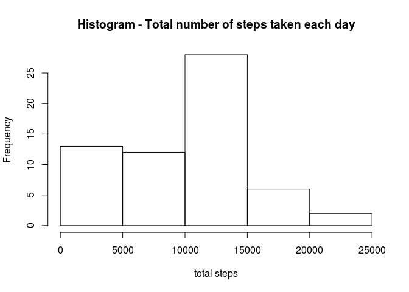

```r
hist(total_steps_perday, main="Histogram - Total number of steps taken each day", xlab = "total steps")
```

3. Calculate and report the mean and median of the total number of steps taken per day

```r
mean(total_steps_perday)
```

```
## [1] 9354.23
```

```r
median(total_steps_perday)
```

```
## [1] 10395
```

## What is the average daily activity pattern?

1. Make a time series plot (i.e. type = “l”) of the 5-minute interval (x-axis) and the average number of steps taken, averaged across all days (y-axis)

[figure not shown]

```r
ggplot(activity) +
  stat_summary(aes(x=interval, y=steps),
               fun.y = function(y) mean(y),
               geom = "line") +
  labs(x = "Avg steps taken") +
  labs(title = "Average Daily Activity")
```

2. Which 5-minute interval, on average across all the days in the dataset, contains the maximum number of steps?

```r
mean_steps_perinterval <- tapply(activity$steps, activity$interval, mean, na.rm=TRUE)
mean_steps_perinterval[mean_steps_perinterval == max(mean_steps_perinterval)]
```

```
##      835
## 206.1698
```

## Imputing missing values

1. Calculate and report the total number of missing values in the dataset (i.e. the total number of rows with NAs)

```r
sum(!complete.cases(activity))
```

```
## [1] 2304
```

2. Devise a strategy for filling in all of the missing values in the dataset - Fill missing values with mean for that 5-minute interval
3. Create a new dataset that is equal to the original dataset but with the missing data filled in.

```r
activity_full <- activity
activity_na <- is.na(activity_full$steps)
activity_full[activity_na, "steps"] <- mean_steps_perinterval[as.character(activity_full[activity_na,"interval"])]
```

4. Make a histogram of the total number of steps taken each day and Calculate and report the mean and median total number of steps taken per day.

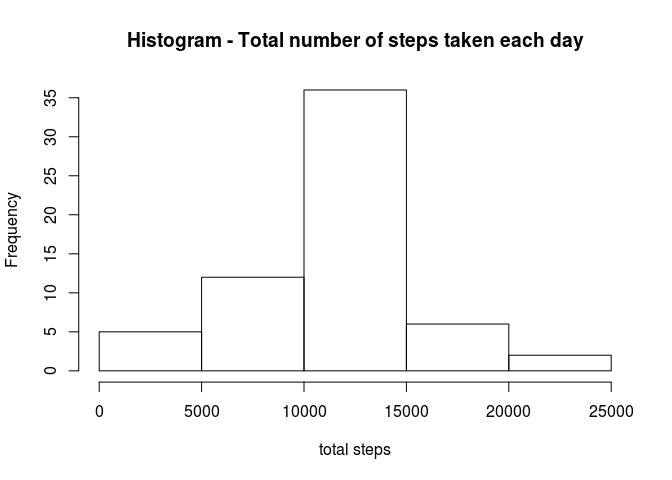

```r
total_steps_perday2 <- tapply(activity_full$steps, activity_full$date, sum, na.rm=TRUE)
hist(total_steps_perday2, main="Histogram - Total number of steps taken each day", xlab = "total steps")
```

```r
mean(total_steps_perday2)
```

```
## [1] 10766.19
```

```r
median(total_steps_perday2)
```

```
## [1] 10766.19
```

Do these values differ from the estimates from the first part of the assignment? Yes, they differ

## Are there differences in activity patterns between weekdays and weekends?

1. Create a new factor variable in the dataset with two levels – “weekday” and “weekend” indicating whether a given date is a weekday or weekend day.

```r
wd <- weekdays(activity_full$date)
activity_full$day_type <- sapply(wd, function(wd) if (wd=="Saturday" || wd == "Sunday") {"weekend"} else {"weekday"})
```

2. Make a panel plot containing a time series plot (i.e. type = “l”) of the 5-minute interval (x-axis) and the average number of steps taken, averaged across all weekday days or weekend days (y-axis)

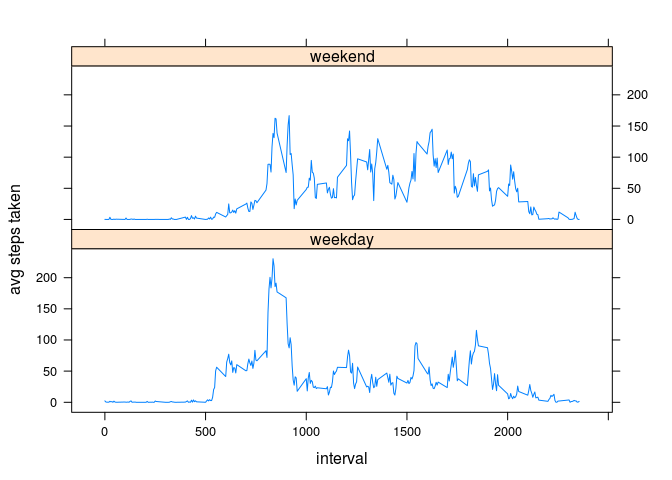

```r
agg_activity <- aggregate(x = activity_full$steps, by = list(interval = activity_full$interval, day_type = activity_full$day_type), FUN = mean)
agg_activity$day_type <- factor(agg_activity$day_type)
xyplot(agg_activity$x ~ agg_activity$interval | agg_activity$day_type, layout = c(1,2), type="l",
       xlab = "interval", ylab = "avg steps taken")
```